# Online Retail Analysis

```python
# Examine descriptions associated with returned transactions
df[df['StockCode'].astype('str').str.contains('C')]['Description']
```

```
87           JUMBO  BAG BAROQUE BLACK WHITE
91        BLUE 3 PIECE POLKADOT CUTLERY SET
121          PINK BREAKFAST CUP AND SAUCER
154         SET OF 3 COLOURED  FLYING DUCKS
176          JUMBO  BAG BAROQUE BLACK WHITE
                        ...
540905         CRYSTAL DIAMANTE STAR BROOCH
541537       JUMBO  BAG BAROQUE BLACK WHITE
541649    CHARLIE+LOLA"EXTREMELY BUSY" SIGN
541778      CHILDRENS CUTLERY POLKADOT BLUE
541809       JUMBO  BAG BAROQUE BLACK WHITE
Name: Description, Length: 6723, dtype: object
```

```python
# Examine suspicious transactions whose StockCode starts with a letter
# to identify non-standard product codes and service/accounting entries

df[df['StockCode'].astype(str).str.match(r'^[A-Za-z]')].groupby('StockCode').head(1)

# Several distinct types of entries were identified:
# POST / DOT / C2  -> postage, delivery and carriage charges
# D                -> discounts
# M / m            -> manual adjustments
# BANK CHARGES     -> bank charges
# AMAZONFEE        -> Amazon marketplace fees
# CRUK             -> commission-related charges
# B                -> bad-debt adjustments
# S                -> samples
# gift_0001_*      -> gift vouchers
# DCGS*            -> mostly actual products rather than accounting entries
# PADS             -> an actual product with an unusually low UnitPrice
#
# Therefore, StockCodes starting with letters cannot simply be classified
# as invalid or non-product transactions. Their meaning must be considered
# separately depending on the analytical task.
```

|  | InvoiceNo | StockCode | Description | Quantity | InvoiceDate | UnitPrice | CustomerID | Country |
| --- | --- | --- | --- | --- | --- | --- | --- | --- |
| 45 | 536370 | POST | POSTAGE | 3 | 2010-12-01 08:45:00 | 18.000 | 12583.0 | France |
| 141 | C536379 | D | Discount | -1 | 2010-12-01 09:41:00 | 27.500 | 14527.0 | United Kingdom |
| 1423 | 536540 | C2 | CARRIAGE | 1 | 2010-12-01 14:05:00 | 50.000 | 14911.0 | EIRE |
| 1814 | 536544 | DOT | DOTCOM POSTAGE | 1 | 2010-12-01 14:32:00 | 569.770 | NaN | United Kingdom |
| 2239 | 536569 | M | Manual | 1 | 2010-12-01 15:35:00 | 1.250 | 16274.0 | United Kingdom |
| 4406 | 536779 | BANK CHARGES | Bank Charges | 1 | 2010-12-02 15:08:00 | 15.000 | 15823.0 | United Kingdom |
| 14436 | C537581 | S | SAMPLES | -1 | 2010-12-07 12:03:00 | 12.950 | NaN | United Kingdom |
| 14514 | C537600 | AMAZONFEE | AMAZON FEE | -1 | 2010-12-07 12:41:00 | 1.000 | NaN | United Kingdom |
| 21326 | 538071 | DCGS0076 | SUNJAR LED NIGHT NIGHT LIGHT | 1 | 2010-12-09 14:09:00 | 16.130 | NaN | United Kingdom |
| 24906 | 538349 | DCGS0003 | BOXED GLASS ASHTRAY | 1 | 2010-12-10 14:59:00 | 2.510 | NaN | United Kingdom |
| 38248 | 539492 | gift_0001_40 | Dotcomgiftshop Gift Voucher £40.00 | 1 | 2010-12-20 10:14:00 | 34.040 | NaN | United Kingdom |
| 40052 | 539718 | DCGS0070 | CAMOUFLAGE DOG COLLAR | 1 | 2010-12-21 13:06:00 | 12.720 | NaN | United Kingdom |
| 40383 | 539736 | m | Manual | 1 | 2010-12-21 15:18:00 | 2.550 | NaN | United Kingdom |
| 42057 | 539958 | gift_0001_50 | Dotcomgiftshop Gift Voucher £50.00 | 1 | 2010-12-23 13:26:00 | 42.550 | NaN | United Kingdom |
| 44725 | 540238 | gift_0001_30 | Dotcomgiftshop Gift Voucher £30.00 | 1 | 2011-01-05 14:44:00 | 25.530 | NaN | United Kingdom |
| 44794 | 540238 | gift_0001_20 | Dotcomgiftshop Gift Voucher £20.00 | 1 | 2011-01-05 14:44:00 | 17.020 | NaN | United Kingdom |
| 74825 | 542529 | DCGS0055 | NaN | -1 | 2011-01-28 13:08:00 | 0.000 | NaN | United Kingdom |
| 74838 | 542531 | DCGS0072 | NaN | -1 | 2011-01-28 13:08:00 | 0.000 | NaN | United Kingdom |
| 74839 | 542532 | DCGS0074 | NaN | -1 | 2011-01-28 13:09:00 | 0.000 | NaN | United Kingdom |
| 75053 | 542541 | DCGS0069 | OOH LA LA DOGS COLLAR | 1 | 2011-01-28 14:25:00 | 15.790 | NaN | United Kingdom |
| 75295 | 542582 | DCGS0057 | NaN | -6 | 2011-01-28 15:01:00 | 0.000 | NaN | United Kingdom |
| 84016 | 543358 | DCGSSBOY | BOYS PARTY BAG | 1 | 2011-02-07 14:04:00 | 3.290 | NaN | United Kingdom |
| 84017 | 543358 | DCGSSGIRL | GIRLS PARTY BAG | 3 | 2011-02-07 14:04:00 | 3.290 | NaN | United Kingdom |
| 112442 | 545895 | gift_0001_10 | Dotcomgiftshop Gift Voucher £10.00 | 1 | 2011-03-07 17:14:00 | 8.330 | NaN | United Kingdom |
| 157195 | 550193 | PADS | PADS TO MATCH ALL CUSHIONS | 1 | 2011-04-15 09:27:00 | 0.001 | 13952.0 | United Kingdom |
| 170783 | 551340 | DCGS0004 | HAYNES CAMPER SHOULDER BAG | 1 | 2011-04-27 17:23:00 | 16.630 | NaN | United Kingdom |
| 279251 | 561249 | DCGS0073 | ebay | -4 | 2011-07-26 11:51:00 | 0.000 | NaN | United Kingdom |
| 279252 | 561250 | DCGS0071 | NaN | -2 | 2011-07-26 11:51:00 | 0.000 | NaN | United Kingdom |
| 279255 | 561253 | DCGS0068 | ebay | -10 | 2011-07-26 11:52:00 | 0.000 | NaN | United Kingdom |
| 279256 | 561254 | DCGS0067 | ebay | -11 | 2011-07-26 11:52:00 | 0.000 | NaN | United Kingdom |
| 279257 | 561255 | DCGS0066P | NaN | -3 | 2011-07-26 11:52:00 | 0.000 | NaN | United Kingdom |
| 299982 | A563185 | B | Adjust bad debt | 1 | 2011-08-12 14:50:00 | 11062.060 | NaN | United Kingdom |
| 317508 | C564763 | CRUK | CRUK Commission | -1 | 2011-08-30 10:49:00 | 1.600 | 14096.0 | United Kingdom |

```python
# Examine the frequency of non-standard StockCodes
# to identify the most common special transaction types
df[df['StockCode'].astype(str).str.match(r'^[A-Za-z]')][
    'StockCode'
].value_counts()

# Special StockCodes occur with very different frequencies.
# POST, DOT and M are among the most common, indicating that
# non-product transactions represent a noticeable part of the dataset.
```

```
StockCode
POST            1256
DOT              710
M                571
C2               144
D                 77
S                 63
BANK CHARGES      37
AMAZONFEE         34
CRUK              16
DCGSSGIRL         13
DCGSSBOY          11
gift_0001_20      10
gift_0001_10       9
gift_0001_30       8
DCGS0003           5
gift_0001_50       4
PADS               4
gift_0001_40       3
B                  3
DCGS0076           2
DCGS0070           2
DCGS0069           2
m                  1
DCGS0055           1
DCGS0072           1
DCGS0074           1
DCGS0057           1
DCGS0004           1
DCGS0073           1
DCGS0071           1
DCGS0068           1
DCGS0067           1
DCGS0066P          1
Name: count, dtype: int64
```

```python
# Examine the completeness of DCGS transactions
df[df['StockCode'].astype(str).str.contains('DCGS')].count()

# All 45 DCGS transactions are missing CustomerID,
# suggesting that these entries may require separate treatment
# despite some of their descriptions resembling regular products.
```

```
InvoiceNo      45
StockCode      45
Description    38
Quantity       45
InvoiceDate    45
UnitPrice      45
CustomerID      0
Country        45
dtype: int64
```

```python
# Examine suspicious entries with negative UnitPrice
df[df['UnitPrice']<0]

# These entries are accounting adjustments rather than actual products
# They should be handled separately in subsequent calculations
```

|  | InvoiceNo | StockCode | Description | Quantity | InvoiceDate | UnitPrice | CustomerID | Country |
| --- | --- | --- | --- | --- | --- | --- | --- | --- |
| 299983 | A563186 | B | Adjust bad debt | 1 | 2011-08-12 14:51:00 | -11062.06 | NaN | United Kingdom |
| 299984 | A563187 | B | Adjust bad debt | 1 | 2011-08-12 14:52:00 | -11062.06 | NaN | United Kingdom |

```python
# Check for duplicate records
df[df.duplicated()]

# A considerable number of duplicates is present and should be addressed during data cleaning
```

|  | InvoiceNo | StockCode | Description | Quantity | InvoiceDate | UnitPrice | CustomerID | Country |
| --- | --- | --- | --- | --- | --- | --- | --- | --- |
| 517 | 536409 | 21866 | UNION JACK FLAG LUGGAGE TAG | 1 | 2010-12-01 11:45:00 | 1.25 | 17908.0 | United Kingdom |
| 527 | 536409 | 22866 | HAND WARMER SCOTTY DOG DESIGN | 1 | 2010-12-01 11:45:00 | 2.10 | 17908.0 | United Kingdom |
| 537 | 536409 | 22900 | SET 2 TEA TOWELS I LOVE LONDON | 1 | 2010-12-01 11:45:00 | 2.95 | 17908.0 | United Kingdom |
| 539 | 536409 | 22111 | SCOTTIE DOG HOT WATER BOTTLE | 1 | 2010-12-01 11:45:00 | 4.95 | 17908.0 | United Kingdom |
| 555 | 536412 | 22327 | ROUND SNACK BOXES SET OF 4 SKULLS | 1 | 2010-12-01 11:49:00 | 2.95 | 17920.0 | United Kingdom |
| ... | ... | ... | ... | ... | ... | ... | ... | ... |
| 541675 | 581538 | 22068 | BLACK PIRATE TREASURE CHEST | 1 | 2011-12-09 11:34:00 | 0.39 | 14446.0 | United Kingdom |
| 541689 | 581538 | 23318 | BOX OF 6 MINI VINTAGE CRACKERS | 1 | 2011-12-09 11:34:00 | 2.49 | 14446.0 | United Kingdom |
| 541692 | 581538 | 22992 | REVOLVER WOODEN RULER | 1 | 2011-12-09 11:34:00 | 1.95 | 14446.0 | United Kingdom |
| 541699 | 581538 | 22694 | WICKER STAR | 1 | 2011-12-09 11:34:00 | 2.10 | 14446.0 | United Kingdom |
| 541701 | 581538 | 23343 | JUMBO BAG VINTAGE CHRISTMAS | 1 | 2011-12-09 11:34:00 | 2.08 | 14446.0 | United Kingdom |

5268 rows × 8 columns

## Data Understanding and Initial Exploration Summary

These findings will guide the decisions made in the data cleaning stage before proceeding with the main analysis.

## Analysis Approach

The analysis is divided into several business-focused areas, including revenue performance, geographical distribution of sales, customer and product behavior, and returns.

For each area, the analysis will begin with a high-level overview of the relevant metrics and patterns. If notable trends, anomalies, or unusual observations are identified, they will be investigated in greater detail to understand the factors behind them.

Since different parts of the analysis require different subsets of the data, data cleaning will be performed separately for each analytical area. Observations that may be irrelevant or problematic for one type of analysis can still contain valuable information for another.

## Data Cleaning

After defining the analytical approach, the next step is to prepare the dataset for further analysis.

Since different analytical sections may require different subsets of the data, most cleaning decisions will be made separately within each section. Potentially important records — such as returns, operational entries, accounting adjustments, and transactions with missing values — will therefore remain in the dataset at this stage.

The main candidate for dataset-wide removal is **exact duplicate records**. Unlike other unusual observations identified during the initial exploration, duplicates do not appear to provide additional information and may artificially affect quantities, revenue, and other calculated metrics.

Before removing them, their structure and frequency will be examined to confirm that treating them as redundant records is justified.

```python
# Examine fully duplicated transaction rows and their frequency
duplicate_counts = df.value_counts(dropna=False).reset_index(name='Count')

duplicate_counts.head(20)

# Exact duplicates contain identical values across all transaction attributes,
# including InvoiceNo, StockCode, Quantity, UnitPrice, CustomerID and InvoiceDate.
# Since Quantity already represents the number of units purchased, repeated
# identical rows are unlikely to represent separate purchases.
#
# Keeping them would artificially inflate quantities, revenue and transaction-level
# statistics. Therefore, exact duplicates will be treated as redundant records
# and removed before further analysis.
```

|  | InvoiceNo | StockCode | Description | Quantity | InvoiceDate | UnitPrice | CustomerID | Country | Count |
| --- | --- | --- | --- | --- | --- | --- | --- | --- | --- |
| 0 | 555524 | 22698 | PINK REGENCY TEACUP AND SAUCER | 1 | 2011-06-05 11:37:00 | 2.95 | 16923.0 | United Kingdom | 20 |
| 1 | 555524 | 22697 | GREEN REGENCY TEACUP AND SAUCER | 1 | 2011-06-05 11:37:00 | 2.95 | 16923.0 | United Kingdom | 12 |
| 2 | 572861 | 22775 | PURPLE DRAWERKNOB ACRYLIC EDWARDIAN | 12 | 2011-10-26 12:46:00 | 1.25 | 14102.0 | United Kingdom | 8 |
| 3 | 538514 | 21756 | BATH BUILDING BLOCK WORD | 1 | 2010-12-12 14:27:00 | 5.95 | 15044.0 | United Kingdom | 6 |
| 4 | 540524 | 21756 | BATH BUILDING BLOCK WORD | 1 | 2011-01-09 12:53:00 | 5.95 | 16735.0 | United Kingdom | 6 |
| 5 | 541266 | 21755 | LOVE BUILDING BLOCK WORD | 1 | 2011-01-16 16:25:00 | 5.95 | 15673.0 | United Kingdom | 6 |
| 6 | 541266 | 21754 | HOME BUILDING BLOCK WORD | 1 | 2011-01-16 16:25:00 | 5.95 | 15673.0 | United Kingdom | 6 |
| 7 | 572344 | M | Manual | 48 | 2011-10-24 10:43:00 | 1.50 | 14607.0 | United Kingdom | 6 |
| 8 | 578289 | 23395 | BELLE JARDINIERE CUSHION COVER | 1 | 2011-11-23 14:07:00 | 3.75 | 17841.0 | United Kingdom | 6 |
| 9 | 537224 | 70007 | HI TEC ALPINE HAND WARMER | 1 | 2010-12-05 16:24:00 | 1.65 | 13174.0 | United Kingdom | 5 |
| 10 | 538517 | 22749 | FELTCRAFT PRINCESS CHARLOTTE DOLL | 1 | 2010-12-12 16:05:00 | 3.75 | 17618.0 | United Kingdom | 5 |
| 11 | 547712 | 22699 | ROSES REGENCY TEACUP AND SAUCER | 1 | 2011-03-24 19:31:00 | 2.95 | 16905.0 | United Kingdom | 5 |
| 12 | 550331 | 85202 | HANGING WOOD AND FELT HEART | 1 | 2011-04-17 13:43:00 | 0.42 | 15555.0 | United Kingdom | 5 |
| 13 | 574481 | 23084 | RABBIT NIGHT LIGHT | 1 | 2011-11-04 12:45:00 | 2.08 | 18022.0 | United Kingdom | 5 |
| 14 | 540524 | 84755 | COLOUR GLASS T-LIGHT HOLDER HANGING | 8 | 2011-01-09 12:53:00 | 0.65 | 16735.0 | United Kingdom | 4 |
| 15 | 541414 | 21755 | LOVE BUILDING BLOCK WORD | 1 | 2011-01-17 16:14:00 | 5.95 | 18212.0 | United Kingdom | 4 |
| 16 | C543611 | 82483 | WOOD 2 DRAWER CABINET WHITE FINISH | -1 | 2011-02-10 14:38:00 | 4.95 | 17850.0 | United Kingdom | 4 |
| 17 | 544450 | 47567B | TEA TIME KITCHEN APRON | 1 | 2011-02-20 12:23:00 | 5.95 | 17811.0 | United Kingdom | 4 |
| 18 | 544463 | 22256 | FELT FARM ANIMAL CHICKEN | 1 | 2011-02-20 14:31:00 | 1.25 | 12988.0 | United Kingdom | 4 |
| 19 | 547651 | 22249 | DECORATION WHITE CHICK MAGIC GARDEN | 1 | 2011-03-24 12:11:00 | 0.85 | 16904.0 | United Kingdom | 4 |

```python
# Remove fully duplicated rows, as they do not represent unique transactions
# and could distort revenue, product, customer, and return-related calculations.
df = df.drop_duplicates().reset_index(drop=True)

df.shape
```

```
(536641, 8)
```

## Revenue Performance

The first part of the analysis focuses on the financial performance of the store.

Revenue will be calculated at the transaction level as:

**Revenue = Quantity × UnitPrice**

The analysis will begin with a high-level overview of revenue and its development over time. The main goal is to identify general trends, periods of particularly strong or weak performance, and any unusual fluctuations in the data.

### Revenue definition

For this section, the analysis focuses on revenue generated from actual sales rather than returns, losses, or operational/accounting adjustments.

Transactions with negative quantities or negative unit prices are excluded from the revenue dataset. Returns will be analyzed separately in the dedicated returns section.

Several special StockCodes are also excluded because they represent non-product or operational/accounting entries rather than merchandise revenue. These include postage and carriage charges (`POST`, `DOT`, `C2`), discounts (`D`), manual adjustments (`M`, `m`), bank charges (`BANK CHARGES`), marketplace and commission-related fees (`AMAZONFEE`, `CRUK`), bad-debt adjustments (`B`), and samples (`S`).

Other unusual StockCodes identified during data exploration are retained when they represent actual products or transactions relevant to store sales.

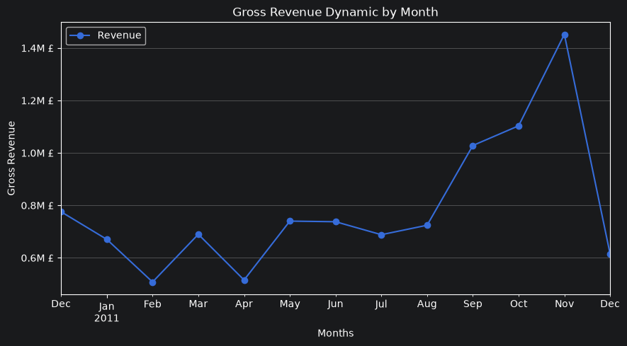

```python
# Create a revenue-specific subset by excluding returns, non-positive prices,
# and operational/accounting entries that do not represent merchandise revenue.
non_revenue_codes = ['POST','DOT','C2','D','M','m','BANK CHARGES','AMAZONFEE','CRUK','B','S']

revenue_df=df[(df['Quantity']>0) & (df['UnitPrice']>0) & (~df['StockCode'].astype(str).isin(non_revenue_codes))].copy()

revenue_df['Revenue']=revenue_df['Quantity']*revenue_df['UnitPrice']

# Analyze the monthly revenue dynamics to identify general trends and unusual periods.

monthly_dynamic=revenue_df.resample('ME', on='InvoiceDate')['Revenue'].sum().reset_index()
monthly_dynamic['InvoiceDate']=monthly_dynamic['InvoiceDate'].dt.to_period('M')
ax = monthly_dynamic.plot(y='Revenue',
                     x='InvoiceDate',
                     kind='line',
                     figsize=(10,5),
                     marker='o')
ax.set_title('Gross Revenue Dynamic by Month')
ax.set_xlabel('Months')
ax.set_ylabel('Gross Revenue')
ax.grid(axis='y')

from matplotlib.ticker import FuncFormatter

ax.yaxis.set_major_formatter(
    FuncFormatter(lambda x, pos: f'{x / 1_000_000:.1f}M £')
)

# Several notable patterns can be observed:
# - Revenue reaches local lows in February, April, and December 2011.
# - A strong upward trend begins after August 2011 and continues through November,
#   with November showing the highest monthly revenue in the dataset.
# - These unusual declines and the substantial late-year growth require further investigation
#   to understand the factors driving them.
```

### Investigation of the December Revenue Drop

```python
#To investigate the sharp decline in revenue observed in December 2011, we first examine the available transaction period for this month.
revenue_df['InvoiceDate'].max()

#The last recorded transaction in the dataset occurred on 9 December 2011.
```

```
Timestamp('2011-12-09 12:50:00')
```

```python
#To quantify the difference in transaction activity, we calculate the median monthly number of unique orders for the complete observation period, excluding December 2011.
orders_count=(revenue_df[revenue_df['InvoiceDate']
              .between(pd.Timestamp('2010-12-01'), pd.Timestamp('2011-11-30'))]
              .resample('ME', on='InvoiceDate')['InvoiceNo']
              .nunique())
orders_count.median()

#The median number of unique orders per complete month is approximately 1,489 orders.
```

```
np.float64(1488.5)
```

```python
#We then calculate the number of unique orders recorded during the available part of December 2011.
revenue_df[revenue_df['InvoiceDate'].between(pd.Timestamp('2011-12-01'), pd.Timestamp('2011-12-31'))]['InvoiceNo'].nunique()
```

```
816
```

Only 816 unique orders were recorded in December 2011.

This indicates that the sharp decline in December revenue is primarily explained by the incomplete observation period and the resulting lower number of recorded orders, rather than by a sudden deterioration in the store's performance.

### Investigation of Revenue Declines in February and April

```python
# Compare the number of unique orders across months to determine whether
# lower transaction volume may explain the revenue declines in February and April.
revenue_df.resample('ME', on='InvoiceDate')['InvoiceNo'].nunique().sort_values()

#Both February and April 2011 are among the months with the lowest number of unique orders, suggesting that lower transaction volume may contribute to their weaker revenue performance.
```

```
InvoiceDate
2011-12-31     816
2011-01-31    1081
2011-02-28    1093
2011-04-30    1235
2011-08-31    1339
2011-03-31    1440
2011-07-31    1452
2011-06-30    1525
2010-12-31    1550
2011-05-31    1668
2011-09-30    1818
2011-10-31    2005
2011-11-30    2751
Name: InvoiceNo, dtype: int64
```

```python
# Compare the distribution of transaction revenue from February to May.
# March and May provide useful reference points, as their total monthly revenue
# is relatively close to the typical level observed in the dataset.
monthly_revenue_quantiles = revenue_df[revenue_df['InvoiceDate'].between(pd.Timestamp('2011-02-01'),pd.Timestamp('2011-05-31'))].resample('ME', on='InvoiceDate')['Revenue'].quantile([0.25,0.5, 0.75, 0.85, 0.9, 0.95, 0.98]).reset_index().copy()

monthly_revenue_quantiles=monthly_revenue_quantiles.rename(columns={'level_1':'Quantiles'})

revenue_quantiles_pivot=monthly_revenue_quantiles.pivot_table(index='InvoiceDate',
                                  columns='Quantiles',
                                  values='Revenue')

revenue_quantiles_pivot

#The upper quantiles reveal a noticeable difference between the two low-revenue months.

#April shows substantially lower values in the upper tail of the distribution, particularly at the 95th and 98th percentiles. Combined with its relatively low number of orders, this suggests that April's revenue decline was driven by both **lower transaction volume and fewer high-value transactions**.

#February, however, remains relatively close to March across most quantiles. Despite having the lowest complete-month revenue, its high-value transactions do not appear unusually weak. This suggests that the February decline cannot be explained by transaction values alone.
```

| Quantiles InvoiceDate | 0.25 | 0.50 | 0.75 | 0.85 | 0.90 | 0.95 | 0.98 |
| --- | --- | --- | --- | --- | --- | --- | --- |
| 2011-02-28 | 4.20 | 10.2 | 17.7 | 23.8 | 31.80 | 60.0 | 120.00 |
| 2011-03-31 | 4.13 | 10.2 | 17.7 | 23.4 | 32.85 | 61.2 | 127.50 |
| 2011-04-30 | 4.13 | 10.2 | 17.7 | 23.4 | 30.00 | 50.7 | 101.76 |
| 2011-05-31 | 4.92 | 11.7 | 19.8 | 25.5 | 35.40 | 67.5 | 132.00 |

```python
# Compare the number of active trading days, defined as days with at least one order,
# to determine whether fewer active days contributed to the lower monthly revenue.
monthly_activity_comparison = revenue_df[
    revenue_df['InvoiceDate'].between('2011-02-01', '2011-05-31')
].groupby(revenue_df['InvoiceDate'].dt.to_period('M')).agg(
    Orders=('InvoiceNo', 'nunique'),
    ActiveDays=('InvoiceDate', lambda x: x.dt.date.nunique()),
    Revenue=('Revenue', 'sum')
)

monthly_activity_comparison

#April contains only 21 active days, the lowest value among the compared months, providing an additional explanation for its relatively low revenue.

#February, in contrast, contains 24 active days, equal to May and only slightly below March. Therefore, the unusually low February revenue cannot be attributed simply to a smaller number of active trading days.
```

| InvoiceDate | Orders | ActiveDays | Revenue |
| --- | --- | --- | --- |
| 2011-02 | 1093 | 24 | 507866.540 |
| 2011-03 | 1440 | 27 | 689841.840 |
| 2011-04 | 1235 | 21 | 515469.661 |
| 2011-05 | 1614 | 24 | 718179.580 |

```python
# Estimate February revenue under a hypothetical scenario in which the number
# of orders was equal to May, while preserving each month's average revenue per transaction.
# This comparison is reasonable because February and May show broadly similar
# transaction-value distributions across the examined quantiles.
what_if_february=revenue_df[revenue_df['InvoiceDate'].between('2011-02-01', '2011-02-28')]['Revenue'].mean()*revenue_df[revenue_df['InvoiceDate'].between('2011-05-01', '2011-05-31')]['InvoiceNo'].nunique()

what_if_may=revenue_df[revenue_df['InvoiceDate'].between('2011-05-01', '2011-05-31')]['Revenue'].mean()*revenue_df[revenue_df['InvoiceDate'].between('2011-05-01', '2011-05-31')]['InvoiceNo'].nunique()

what_if_may, what_if_february, round((what_if_may/what_if_february-1)*100, 2), round((monthly_activity_comparison.loc['2011-05','Revenue']/monthly_activity_comparison.loc['2011-02', 'Revenue']-1)*100, 2)

#Under the hypothetical scenario with the same number of orders, the estimated revenue difference between February and May decreases to only 7.07%, compared with the actual difference of 41.41%.

#This strongly suggests that February's exceptionally low gross revenue was driven primarily by its low number of orders, rather than substantially lower transaction values.

#The available data does not provide enough information to determine the underlying reason for the reduced order volume in February.
```

```
(np.float64(33606.10698480807),
 np.float64(31386.672833406385),
 np.float64(7.07),
 np.float64(41.41))
```

The analysis suggests that the revenue declines in **April and February 2011** were driven by different factors:

- **April:** lower gross revenue can be explained by a combination of a relatively **low number of orders** and a **weaker presence of high-value transactions**, as indicated by the lower upper quantiles.
- **February:** the transaction-value distribution remained broadly comparable to stronger months, while the number of orders was particularly low. The hypothetical comparison with May reduced the revenue gap from **41.41% to only 7.07%** after controlling for the difference in order volume. Therefore, February's weak performance appears to have been driven primarily by the **low number of orders**.

The available transactional data does not provide sufficient information to determine why order activity was unusually low in February.

### Investigation of the September–November Revenue Growth and November Peak

```python
# We return to the monthly order count to examine the period of strong revenue growth.
revenue_df.resample('ME', on='InvoiceDate')['InvoiceNo'].nunique().sort_values(ascending=False)

# September–November stands out as a period of rapidly increasing order activity,
# with November reaching by far the highest number of orders in the dataset.
```

```
InvoiceDate
2011-11-30    2751
2011-10-31    2005
2011-09-30    1818
2011-05-31    1668
2010-12-31    1550
2011-06-30    1525
2011-07-31    1452
2011-03-31    1440
2011-08-31    1339
2011-04-30    1235
2011-02-28    1093
2011-01-31    1081
2011-12-31     816
Name: InvoiceNo, dtype: int64
```

```python
# Next, we examine the revenue quantiles across all months to assess whether
# the strong September–November performance was driven by unusually high-value transactions.
monthly_revenue_quantiles = revenue_df.resample('ME', on='InvoiceDate')['Revenue'].quantile([0.25,0.5, 0.75, 0.85, 0.9, 0.95, 0.98]).reset_index().copy()

monthly_revenue_quantiles=monthly_revenue_quantiles.rename(columns={'level_1':'Quantiles'})

monthly_revenue_quantiles_pivot=monthly_revenue_quantiles.pivot_table(index='InvoiceDate',
                                  columns='Quantiles',
                                  values='Revenue')

monthly_revenue_quantiles_pivot

# As shown below, September–November do not stand out in the upper quantiles,
# with transaction values remaining broadly comparable to those observed in other months.
```

| Quantiles InvoiceDate | 0.25 | 0.50 | 0.75 | 0.85 | 0.90 | 0.95 | 0.98 |
| --- | --- | --- | --- | --- | --- | --- | --- |
| 2010-12-31 | 3.75 | 8.47 | 17.40 | 25.20 | 33.880 | 59.400 | 105.000 |
| 2011-01-31 | 3.75 | 8.29 | 16.50 | 21.05 | 30.000 | 51.000 | 102.000 |
| 2011-02-28 | 4.20 | 10.20 | 17.70 | 23.80 | 31.800 | 60.000 | 120.000 |
| 2011-03-31 | 4.13 | 10.20 | 17.70 | 23.40 | 32.850 | 61.200 | 127.500 |
| 2011-04-30 | 4.13 | 10.20 | 17.70 | 23.40 | 30.000 | 50.700 | 101.760 |
| 2011-05-31 | 4.92 | 11.70 | 19.80 | 25.50 | 35.400 | 67.500 | 130.902 |
| 2011-06-30 | 4.13 | 9.96 | 17.70 | 24.78 | 32.700 | 59.712 | 122.400 |
| 2011-07-31 | 3.30 | 8.50 | 17.00 | 21.00 | 30.000 | 52.200 | 105.120 |
| 2011-08-31 | 4.25 | 10.50 | 19.80 | 25.20 | 34.680 | 66.492 | 145.000 |
| 2011-09-30 | 4.25 | 10.50 | 19.80 | 25.20 | 34.500 | 61.200 | 122.400 |
| 2011-10-31 | 3.75 | 9.95 | 17.70 | 23.80 | 30.000 | 50.850 | 105.600 |
| 2011-11-30 | 3.29 | 8.26 | 16.65 | 22.50 | 30.000 | 51.000 | 102.000 |
| 2011-12-31 | 3.29 | 8.26 | 17.00 | 23.60 | 31.235 | 52.507 | 102.000 |

The strong revenue growth observed from September to November was primarily driven by a substantial increase in the number of orders rather than by higher-value transactions.

November stands out particularly strongly, reaching **2,751 unique orders** — the highest monthly order count in the entire dataset. At the same time, transaction-value quantiles remained broadly comparable to other months.

Therefore, the late-year revenue growth can be attributed mainly to **increased order volume**, with November representing the peak of this trend.

## Revenue Performance Summary

Based on the analysis above, we can confidently conclude that the **main driver of the store's revenue is sales volume**, rather than substantial changes in transaction values.

### December 2010 – August 2011

From December 2010 through August 2011, the store showed relatively moderate performance. This period also contains the two most notable revenue declines: **February and April**.

- **April** was characterized by a relatively low number of transactions and the weakest presence of high-value transactions.
- **February**, on the other hand, performed poorly primarily because of **low sales volume**. A hypothetical calculation estimating February's revenue if it had recorded approximately as many orders as the neighboring stronger months showed that its revenue would have been close to a typical monthly level.

The available data does not provide enough information to determine why transaction activity declined so substantially in February.

### September – November 2011

From September through November — the final month with a complete observation period — the store experienced **sustained revenue growth**.

Once again, this increase was primarily driven by a growing number of transactions, while transaction values remained broadly within the same ranges observed earlier in the dataset.

### December 2011

December 2011 should be interpreted separately because the dataset contains only **nine days of observations** for that month. This makes it difficult to evaluate the month's overall performance directly.

Nevertheless, during those nine days, December had already generated more revenue than the complete months of February and April, suggesting **strong revenue potential despite the incomplete observation period**.

## Geographic Analysis

This section explores the **geographic structure of the store's business activity** and the role that different markets play in generating transactions and revenue.

The main objective is to understand whether the store's activity is concentrated primarily in the **United Kingdom** or whether international markets also make a significant contribution. Particular attention is given to the importance of foreign trade, the countries that generate the highest revenue and transaction volumes, and differences in the typical value of their orders.

The analysis also aims to identify the store's most important international trade channels and determine whether any broader geographic pattern can be observed among them — for example, a concentration in **European markets, former British colonies, or a more geographically diverse group of countries**.

The exact direction of the analysis is guided by the patterns observed in the data, with notable geographic differences investigated in greater detail where necessary.

### Geographic Data Preparation

```python
# Examine the countries associated with the store's orders.
revenue_df.groupby('Country').nunique()

# Two entries stand out as not representing specific countries:
# 'European Community' and 'Unspecified'.
```

| Country | InvoiceNo | StockCode | Description | Quantity | InvoiceDate | UnitPrice | CustomerID | Revenue |
| --- | --- | --- | --- | --- | --- | --- | --- | --- |
| Australia | 56 | 598 | 607 | 53 | 54 | 74 | 9 | 345 |
| Austria | 17 | 305 | 305 | 20 | 17 | 42 | 11 | 96 |
| Bahrain | 3 | 16 | 16 | 9 | 3 | 9 | 2 | 11 |
| Belgium | 98 | 776 | 783 | 32 | 98 | 63 | 25 | 174 |
| Brazil | 1 | 32 | 32 | 7 | 1 | 16 | 1 | 19 |
| Canada | 5 | 146 | 146 | 19 | 5 | 29 | 4 | 56 |
| Channel Islands | 25 | 428 | 434 | 23 | 25 | 53 | 9 | 140 |
| Cyprus | 14 | 496 | 496 | 26 | 14 | 53 | 8 | 178 |
| Czech Republic | 2 | 24 | 24 | 8 | 2 | 15 | 1 | 21 |
| Denmark | 18 | 250 | 251 | 29 | 18 | 42 | 9 | 117 |
| EIRE | 282 | 1966 | 2015 | 62 | 281 | 109 | 3 | 570 |
| European Community | 3 | 49 | 49 | 8 | 3 | 18 | 1 | 28 |
| Finland | 40 | 456 | 463 | 27 | 40 | 50 | 12 | 146 |
| France | 382 | 1539 | 1561 | 55 | 383 | 86 | 87 | 468 |
| Germany | 443 | 1662 | 1694 | 47 | 438 | 95 | 94 | 487 |
| Greece | 5 | 137 | 137 | 15 | 5 | 32 | 4 | 57 |
| Hong Kong | 7 | 189 | 192 | 25 | 7 | 37 | 0 | 98 |
| Iceland | 7 | 103 | 103 | 15 | 7 | 32 | 1 | 56 |
| Israel | 8 | 254 | 255 | 25 | 8 | 55 | 3 | 134 |
| Italy | 35 | 472 | 475 | 23 | 35 | 55 | 14 | 132 |
| Japan | 19 | 215 | 216 | 34 | 20 | 45 | 8 | 139 |
| Lebanon | 1 | 45 | 45 | 9 | 1 | 23 | 1 | 33 |
| Lithuania | 4 | 29 | 29 | 10 | 4 | 10 | 1 | 18 |
| Malta | 5 | 98 | 98 | 13 | 5 | 27 | 2 | 47 |
| Netherlands | 93 | 781 | 801 | 59 | 93 | 79 | 9 | 421 |
| Norway | 32 | 589 | 593 | 30 | 32 | 69 | 10 | 205 |
| Poland | 19 | 203 | 204 | 19 | 19 | 47 | 6 | 96 |
| Portugal | 50 | 704 | 712 | 28 | 50 | 56 | 19 | 229 |
| RSA | 1 | 57 | 57 | 8 | 1 | 22 | 1 | 31 |
| Saudi Arabia | 1 | 9 | 9 | 3 | 1 | 5 | 1 | 5 |
| Singapore | 4 | 177 | 178 | 23 | 4 | 44 | 1 | 91 |
| Spain | 88 | 1090 | 1104 | 35 | 88 | 76 | 30 | 315 |
| Sweden | 34 | 259 | 259 | 40 | 34 | 41 | 8 | 147 |
| Switzerland | 50 | 977 | 986 | 37 | 50 | 66 | 21 | 297 |
| USA | 5 | 163 | 163 | 18 | 5 | 33 | 4 | 73 |
| United Arab Emirates | 2 | 67 | 67 | 10 | 2 | 24 | 2 | 37 |
| United Kingdom | 17901 | 3907 | 3999 | 368 | 16695 | 500 | 3916 | 4050 |
| Unspecified | 13 | 344 | 344 | 20 | 13 | 46 | 4 | 125 |

```python
# Create a new DataFrame for geographic analysis.
# We use revenue_df as the starting point, meaning that returns,
# delivery charges, discounts, and other non-sales transactions
# have already been excluded from the dataset.
#
# Revenue remains the primary metric of interest throughout the
# geographic analysis, as the goal is to examine where the company
# generates its sales income.
#
# Additionally, the categories "Unspecified" and "European Community"
# are removed because they do not represent clearly identifiable
# destination countries and could distort the analysis of customer
# geography and market structure.
geographic_df=revenue_df[~revenue_df['Country'].astype('str').isin(['Unspecified', 'European Community'])]
```

### Overall Trade Structure: UK vs International

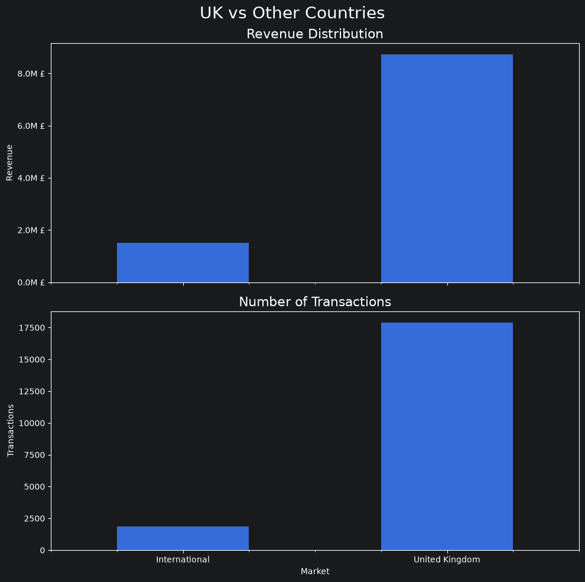

```python
# We use the cleaned geographic dataset and divide the market into two groups:
# the United Kingdom (domestic market) and all other countries (international market).
uk_vs_inter=geographic_df.copy()
uk_vs_inter['Market']=np.where(uk_vs_inter['Country']=='United Kingdom', 'United Kingdom', 'International')

# We compare both total revenue and the number of unique transactions
# to examine the overall structure of domestic and international sales.
uk_vs_inter_plot_1=uk_vs_inter.groupby('Market')['Revenue'].sum()
uk_vs_inter_plot_2=uk_vs_inter.groupby('Market')['InvoiceNo'].nunique()

fig, axes = plt.subplots(2,1, figsize=(10,10), sharex=True)

uk_vs_inter_plot_1.plot(x='Market', y='Revenue', kind='bar', ax=axes[0])
uk_vs_inter_plot_2.plot(x='Market', y='InvoiceNo', kind='bar', ax=axes[1])

axes[0].yaxis.set_major_formatter(
    FuncFormatter(lambda x, pos: f'{x / 1_000_000:.1f}M £')
)
axes[0].set_title('Revenue Distribution', fontsize=16)
axes[1].set_title('Number of Transactions', fontsize=16)
plt.suptitle('UK vs Other Countries', fontsize=20)

axes[0].set_ylabel('Revenue')
axes[1].set_ylabel('Transactions')

plt.xticks(rotation=0)

plt.tight_layout()

# The results show a strong concentration of sales in the domestic market.
# The United Kingdom accounts for the vast majority of both total revenue
# and unique transactions, while international markets represent a much smaller share
```

```python
# We calculate the share of total revenue and unique transactions generated by international markets.
comparison_1=round(uk_vs_inter[uk_vs_inter['Market']=='International']['Revenue'].sum()/uk_vs_inter['Revenue'].sum()*100, 3)
comparison_2=round(uk_vs_inter[uk_vs_inter['Market']=='International']['InvoiceNo'].nunique()/uk_vs_inter['InvoiceNo'].nunique()*100, 3)

comparison_1, comparison_2

# International markets account for 14.81% of total revenue but only 9.39% of all transactions.
# This confirms that the store's activity is primarily concentrated in the United Kingdom,
# while also suggesting that international orders tend to have higher values.
```

```
(np.float64(14.81), 9.394)
```

```python
# To investigate this difference, we compare the distribution of transaction values
# between the United Kingdom and international markets using quantiles.
comparison_single_revenue=uk_vs_inter.groupby('Market')['Revenue'].quantile([0.25, 0.5, 0.75, 0.9, 0.95, 0.98, 0.99, 1]).reset_index()

comparison_single_revenue=comparison_single_revenue.rename(columns={'level_1':'Quantiles'})

comparison_single_revenue.pivot(index='Market', columns='Quantiles', values='Revenue')

# The results support the previous observation: international transactions are consistently
# more valuable across the distribution, with substantially higher values at all examined quantiles.
# The absolute maximum, however, belongs to the United Kingdom, where one transaction
# reached £168,469.60.
```

| Quantiles Market | 0.25 | 0.50 | 0.75 | 0.90 | 0.95 | 0.98 | 0.99 | 1.00 |
| --- | --- | --- | --- | --- | --- | --- | --- | --- |
| International | 13.2 | 17.4 | 29.88 | 69.6 | 132.00 | 230.4 | 306.0000 | 4992.0 |
| United Kingdom | 3.4 | 8.5 | 17.00 | 30.0 | 49.95 | 100.8 | 172.1856 | 168469.6 |

However, international transactions tend to have a **higher-value structure**, with transaction values consistently exceeding those observed in the UK across most of the distribution.

Overall, the UK remains the store's core market, while international sales represent a smaller but **higher-value segment of its business**.

### International Trade Structure

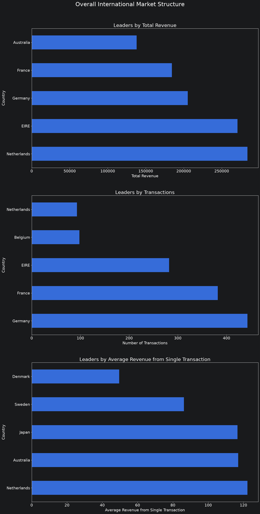

```python
# We compare the top five international markets by three dimensions:
# total revenue, number of unique transactions, and average revenue per transaction.

# Create a separate DataFrame containing only international markets
# by excluding the United Kingdom from the geographic dataset.
international_df=geographic_df[geographic_df['Country']!='United Kingdom']

# Prepare the top five countries for three complementary measures:
# total revenue, number of unique transactions, and average revenue per transaction line.
# These datasets will be used to compare different sources of international market strength.
overall_structure_1=international_df.groupby('Country')['Revenue'].sum().sort_values(ascending=False).head()
overall_structure_2=international_df.groupby('Country')['InvoiceNo'].nunique().sort_values(ascending=False).head()
overall_structure_3=international_df.groupby('Country')['Revenue'].mean().sort_values(ascending=False).head()

fig, axes = plt.subplots(3,1, figsize=(15,30))

overall_structure_1.plot(x='Country', y='Revenue', kind='barh', ax=axes[0])
overall_structure_2.plot(x='Country', y='InvoiceNo', kind='barh', ax=axes[1])
overall_structure_3.plot(x='Country', y='Revenue', kind='barh', ax=axes[2])

axes[0].set_title('Leaders by Total Revenue', fontsize=20)
axes[1].set_title('Leaders by Transactions', fontsize=20)
axes[2].set_title('Leaders by Average Revenue from Single Transaction', fontsize=20)

axes[0].set_xlabel('Total Revenue', fontsize=16)
axes[1].set_xlabel('Number of Transactions', fontsize=16)
axes[2].set_xlabel('Average Revenue from Single Transaction', fontsize=16)

for ax in axes:
    ax.set_ylabel('Country', fontsize=16)
    ax.tick_params(axis='both', labelsize=16)

plt.suptitle('Overall International Market Structure', fontsize=24)
plt.tight_layout(rect=[0,0,1,0.96], h_pad=5)
# The leading countries by total revenue are the Netherlands, EIRE, Germany,
# France, and Australia. However, their strong performance is driven by
# different combinations of transaction volume and transaction value.
#
# The Netherlands combines a very high average transaction value with a place
# among the top markets by transaction count, which explains its leading revenue position.
#
# EIRE performs strongly due to a combination of a relatively high number of
# transactions and comparatively high transaction values.
#
# Germany and France are driven primarily by transaction volume, while Australia
# reaches the top five mainly because of its high average transaction value.
#
# Overall, there is no single pattern that explains international market leadership:
# some countries generate high revenue through volume, while others rely more heavily
# on higher-value transactions.
```

```python
# Calculate how much of the international market is concentrated among
# the five leading countries by total revenue and transaction volume.
# The international market includes 35 countries in total.
share_1=round(overall_structure_1.sum()/international_df['Revenue'].sum()*100, 3)
share_2=round(overall_structure_2.sum()/international_df['InvoiceNo'].nunique()*100, 3)
countries_count=international_df['Country'].nunique()
share_1, share_2, countries_count

# Despite representing only 5 out of 35 international markets,
# the leading countries account for 71.378% of international revenue
# and 69.935% of all international transactions.
# This indicates a strong concentration of foreign trade among a relatively small group of markets.
```

```
(np.float64(71.378), np.float64(69.935), 35)
```

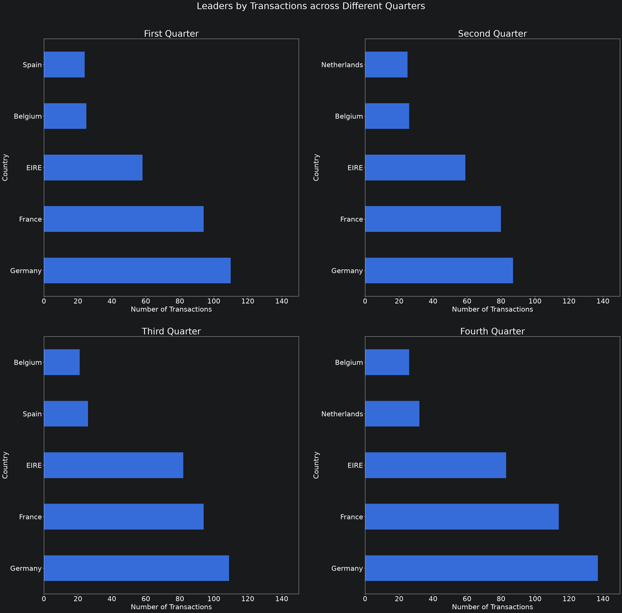

```python
# Analyze the stability of the store's main international trading partners
# by comparing the countries with the highest transaction volumes across quarters.

# Reset the index to avoid conflicts during resampling.
international_df = international_df.reset_index(drop=True)

# Aggregate the number of unique transactions by country and quarter.
quarter_dynamic=international_df.groupby('Country').resample('QE', on='InvoiceDate')['InvoiceNo'].nunique().reset_index()

# Convert quarter-end dates into quarterly periods for easier filtering.
quarter_dynamic['InvoiceDate']=quarter_dynamic['InvoiceDate'].dt.to_period('Q')

# Split the observation period into four groups.
# December 2010 is included together with Q1 2011 due to the limited
# amount of data available for 2010.
first_quarter=quarter_dynamic[quarter_dynamic['InvoiceDate'].astype(str).isin(['2010Q4', '2011Q1'])].groupby('Country')['InvoiceNo'].sum().reset_index()
second_quarter=quarter_dynamic[quarter_dynamic['InvoiceDate']=='2011Q2'].groupby('Country')['InvoiceNo'].sum().reset_index()
third_quarter=quarter_dynamic[quarter_dynamic['InvoiceDate']=='2011Q3'].groupby('Country')['InvoiceNo'].sum().reset_index()
fourth_quarter=quarter_dynamic[quarter_dynamic['InvoiceDate']=='2011Q4'].groupby('Country')['InvoiceNo'].sum().reset_index()

fig, axes= plt.subplots(2,2, figsize=(30,30))

first_quarter.sort_values('InvoiceNo', ascending=False).head().plot(x='Country', y='InvoiceNo', kind='barh', ax=axes[0,0], legend=False)
second_quarter.sort_values('InvoiceNo', ascending=False).head().plot(x='Country',y='InvoiceNo', kind='barh', ax=axes[0,1], legend=False)
third_quarter.sort_values('InvoiceNo', ascending=False).head().plot(x='Country',y='InvoiceNo', kind='barh', ax=axes[1,0], legend=False)
fourth_quarter.sort_values('InvoiceNo', ascending=False).head().plot(x='Country',y='InvoiceNo', kind='barh', ax=axes[1,1], legend=False)

axes[0,0].set_title('First Quarter', fontsize=30)
axes[0,1].set_title('Second Quarter', fontsize=30)
axes[1,0].set_title('Third Quarter', fontsize=30)
axes[1,1].set_title('Fourth Quarter', fontsize=30)

for ax in axes.flat:
    ax.set_ylabel('Country', fontsize=24)
    ax.set_xlabel('Number of Transactions', fontsize=24)
    ax.tick_params(axis='both', labelsize=24)
    ax.set_xlim(0,150)

plt.suptitle('Leaders by Transactions across Different Quarters', fontsize=32)
plt.tight_layout(rect=[0,0,1,0.96], h_pad=5, w_pad=5)

# The quarterly comparison reveals a stable group of the store's main international
# trading partners. Germany, France, EIRE and Belgium consistently appear among
# the countries with the highest transaction volumes, while the Netherlands and
# Spain alternate in the remaining leading position.
#
# This indicates that international trade is supported by persistent trading
# relationships rather than isolated short-term spikes. Although the exact ranking
# changes between quarters, the core geographical structure remains relatively stable.
```

```python
# As an additional check, we examine November 2011 — the month with the highest
# total revenue in the dataset — and identify its five largest international
# markets by number of transactions.
november=international_df[international_df['InvoiceDate'].between('2011-11-01', '2011-11-30')].groupby('Country')['InvoiceNo'].nunique()
november.sort_values(ascending=False).head()

# The same geographical pattern remains visible during the highest-revenue month.
# Germany, France and EIRE remain the three leading international markets,
# while the Netherlands and Spain complete the top five.
#
# This further supports the conclusion that the store has a stable group of
# core international trading partners rather than a structure driven by
# temporary or quarter-specific changes.
```

```
Country
Germany        62
France         59
EIRE           39
Netherlands    14
Spain          13
Name: InvoiceNo, dtype: int64
```

The store's international activity is **highly concentrated around a relatively small group of key markets**. The five leading countries account for approximately **71.38% of international revenue and 69.94% of international transactions**, despite the dataset containing **35 international markets** in total.

However, there is **no single pattern explaining a country's importance**. The Netherlands and Australia stand out due to their relatively high average transaction values, Germany and France are primarily driven by large transaction volumes, while EIRE combines both a high number of transactions and relatively strong transaction values.

The analysis over time reveals a **stable core of international trading partners**. Germany, France, EIRE and Belgium consistently appear among the leading countries by transaction volume across different quarters, while the Netherlands and Spain alternate around the remaining top positions.

This pattern remains visible in **November 2011, the highest-revenue month**, where Germany, France and EIRE once again occupy the top three positions by number of international transactions.

While some international markets, particularly the Netherlands, show substantially higher transaction values, **the available dataset does not provide enough information to determine the underlying reasons for this pattern**.

Overall, the store's international trade is geographically diversified across many countries, but its activity is strongly supported by a **small and persistent group of core markets**, indicating stable international demand rather than dependence on isolated short-term spikes.

## Product Analysis

The goal of this section is to identify the store's **most popular and strongest-performing products** and explore the structure of product demand.

The analysis begins with **the number of units sold as the primary measure of product popularity**, as it provides a direct indication of demand for individual products.

Where necessary, individual findings will be **investigated in greater detail using additional available metrics and characteristics of the data**.

```python
# Create a separate dataframe for product-level analysis.
# Since the goal is to evaluate the performance of actual products, we keep only
# positive-quantity, positive-price transactions and exclude non-product StockCodes
# related to fees, delivery, commissions, adjustments, and other special operations.
#
# Entries with lowercase descriptions are also excluded, as the previous data
# quality analysis showed that they primarily represent operational or technical
# notes rather than regular product names.
non_revenue_codes = ['POST','DOT','C2','D','M','m','BANK CHARGES','AMAZONFEE','CRUK','B','S']

products_df=df[(df['Quantity']>0) & (df['UnitPrice']>0) & (~df['StockCode'].astype(str).isin(non_revenue_codes)) & (df['Description']!=df['Description'].str.lower())].copy().reset_index(drop=True)
# Create a pool of valid product descriptions that can be used to recover
# missing product names based on their StockCode.
# Only non-missing uppercase descriptions are retained, excluding the
# suspicious operational and technical entries identified earlier.
normal_descriptions = df[(df['Description'].notna()) & (df['Description']==df['Description'].str.upper())]
# Check whether each StockCode corresponds to a single valid description.
normal_descriptions.groupby('StockCode')['Description'].nunique().sort_values(
    ascending=False
).head(20)

# Even after filtering suspicious entries, some StockCodes are still associated
# with several different product descriptions and require closer examination.
```

```
StockCode
23131    4
23196    4
23236    4
23126    3
22837    3
22812    3
22776    3
21830    3
22937    3
23203    3
23209    3
23231    3
23240    3
23244    3
23366    3
23370    3
23396    3
23413    3
23535    3
82583    3
Name: Description, dtype: int64
```

```python
normal_descriptions.loc[normal_descriptions['StockCode'] == 23131,'Description'].value_counts()
```

```
Description
MISTLETOE HEART WREATH CREAM    113
MISELTOE HEART WREATH WHITE       4
MISELTOE HEART WREATH CREAM       1
?                                 1
Name: count, dtype: int64
```

```python
normal_descriptions.loc[normal_descriptions['StockCode'] == 23196,'Description'].value_counts()

# Closer examination shows that multiple descriptions for the same StockCode
# do not represent different products. They are mostly highly similar naming
# variations, minor corrections, or different specifications of the same product.
#
# Therefore, StockCode can still be treated as the primary product identifier,
# while the most frequently occurring valid description can be used as its
# representative product name.
```

```
Description
VINTAGE LEAF MAGNETIC NOTEPAD         282
RETRO LEAVES MAGNETIC NOTEPAD          21
RETO LEAVES MAGNETIC SHOPPING LIST      3
LEAVES MAGNETIC  SHOPPING LIST          2
Name: count, dtype: int64
```

```python
# Recover missing product descriptions using the most frequently occurring
# uppercase description associated with the same StockCode.
description_map = (normal_descriptions.groupby('StockCode')['Description'].agg(lambda x: x.value_counts().index[0]))
products_df['Description'] = products_df['Description'].fillna(products_df['StockCode'].map(description_map))
```

```python
# Verify that all missing product descriptions have been successfully recovered.
products_df['Description'].isna().sum()

# No missing descriptions remain, confirming that all missing product names
# were successfully recovered using the StockCode-based mapping.
```

```
np.int64(0)
```

```python
# Examine the relationship between a product's price and its total quantity sold.
# Since the same StockCode may appear with different prices, we simplify the analysis
# by using the most frequently observed UnitPrice for each product.
price_vs_quantity=products_df.groupby('StockCode')[['UnitPrice', 'Quantity']].agg({'UnitPrice': lambda x: x.value_counts().index[0], 'Quantity':'sum'})

price_vs_quantity['UnitPrice'].corr(price_vs_quantity['Quantity'])

# Intuitively, we might expect more expensive products to be purchased less frequently.
# However, the correlation is approximately -0.10, indicating only a very weak negative
# linear relationship between product price and total quantity sold.
#
# Therefore, price alone does not appear to strongly determine how many units of a product
# are sold. This also motivates analyzing product performance from two perspectives:
# the most frequently purchased products and the products generating the highest revenue.
```

```
np.float64(-0.09944997447445121)
```

### Best-Selling Products by Units Sold

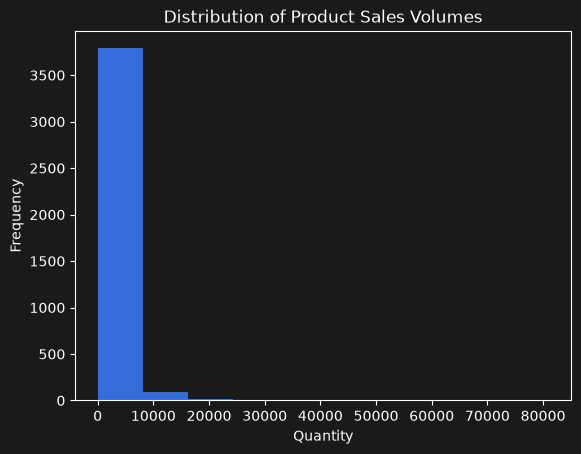

```python
# Analyze the distribution of total units sold across individual products.
popular_products=products_df.groupby('StockCode')['Quantity'].sum()
ax = popular_products.plot(y='Quantity', kind='hist', bins=10)
ax.set_title('Distribution of Product Sales Volumes')
ax.set_xlabel('Quantity')

# The distribution is strongly right-skewed: most products have relatively low
# sales volumes, while a small group reaches approximately 15,000–25,000 units sold.
# These products represent potential candidates for the store's best-selling items.
```

```python
# Check how many products fall within the identified high-sales range.
popular_products[popular_products>15000].count()

# The histogram initially suggested that the high-sales group was concentrated
# around 15,000–25,000 units. However, several products exceed this range and
# are barely visible due to their low frequency.
# In total, only 33 products sold more than 15,000 units, confirming that
# exceptionally high sales volumes are concentrated among a small group of products.
```

```
np.int64(33)
```

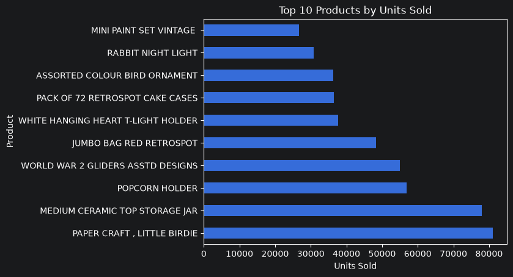

```python
# Examine the top 10 best-selling products by total units sold.
popular_products_plot=products_df.groupby('StockCode')[['Description', 'Quantity', 'UnitPrice']].agg({'Description': lambda x: x.value_counts().index[0], 'Quantity':'sum', 'UnitPrice': lambda x: x.value_counts().index[0]}).sort_values('Quantity', ascending=False).head(10)

bx = popular_products_plot.plot(x='Description', y='Quantity', kind='barh', legend=False)
bx.set_title('Top 10 Products by Units Sold')
bx.set_xlabel('Units Sold')
bx.set_ylabel('Product')

# PAPER CRAFT, LITTLE BIRDIE and MEDIUM CERAMIC TOP STORAGE JAR clearly stand out
# as the two strongest sales leaders, with a substantial gap over the remaining products.
#
# At the same time, the best-selling products do not appear to belong to one clearly
# dominant product category. The top 10 includes a diverse range of items, suggesting
# that high sales volumes are not concentrated within a single type of product.
```

```python
# Compare the prices of the top 10 best-selling products with the median product
# price in the dataset.
popular_products_plot[['Description','UnitPrice']], products_df['UnitPrice'].median()

# Although the previous analysis showed almost no overall correlation between
# product price and total units sold, the strongest sales leaders are generally
# concentrated among relatively inexpensive products.
#
# Nearly all of the top 10 best-selling products are priced at or below the
# overall median price of £2.08. The only exception is the White Hanging Heart
# T-Light Holder, priced at £2.95.
#
# This does not contradict the near-zero correlation observed earlier: price does
# not systematically determine sales volume across all products, but the absolute
# best-sellers in this dataset tend to be relatively low-priced.
```

```
(                                  Description  UnitPrice
 StockCode
 23843             PAPER CRAFT , LITTLE BIRDIE       2.08
 23166          MEDIUM CERAMIC TOP STORAGE JAR       1.25
 22197                          POPCORN HOLDER       0.85
 84077       WORLD WAR 2 GLIDERS ASSTD DESIGNS       0.29
 85099B                JUMBO BAG RED RETROSPOT       2.08
 85123A     WHITE HANGING HEART T-LIGHT HOLDER       2.95
 21212         PACK OF 72 RETROSPOT CAKE CASES       0.55
 84879           ASSORTED COLOUR BIRD ORNAMENT       1.69
 23084                      RABBIT NIGHT LIGHT       2.08
 22492                 MINI PAINT SET VINTAGE        0.65,
 np.float64(2.08))
```

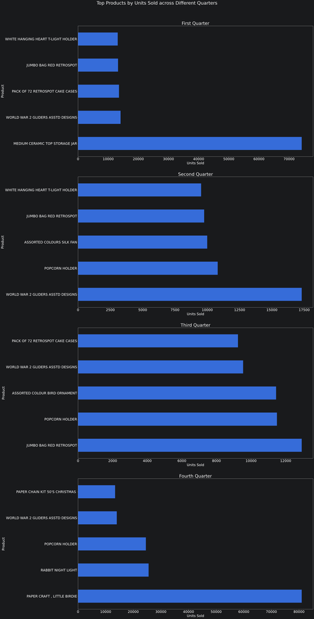

```python
# Aggregate the total quantity sold for each product by quarter to analyze
# whether the store's best-selling products remain stable over time.
popular_products_dynamic=products_df.groupby('StockCode').resample('QE', on='InvoiceDate')['Quantity'].sum().reset_index()

# Since the analysis is based on StockCode, create a separate mapping between
# each product code and its most frequently occurring description in the cleaned dataset.
product_names = products_df.groupby('StockCode')['Description'].agg(lambda x: x.value_counts().index[0])

# Add the corresponding product names back to the quarterly data to make
# the results easier to interpret and visualize.
popular_products_dynamic['Description'] = popular_products_dynamic['StockCode'].map(product_names)

popular_products_dynamic['InvoiceDate']=popular_products_dynamic['InvoiceDate'].dt.to_period('Q')

# Split product sales into quarterly periods to examine whether the store's
# best-selling products remain stable over time.

# December 2010 is combined with Q1 2011 due to the limited amount of data
# available for 2010.
first_quarter=popular_products_dynamic[popular_products_dynamic['InvoiceDate'].astype(str).isin(['2010Q4', '2011Q1'])].groupby('StockCode')[['Quantity', 'Description']].agg({'Quantity': 'sum', 'Description': 'first'})
second_quarter=popular_products_dynamic[popular_products_dynamic['InvoiceDate']=='2011Q2'].groupby('StockCode')[['Quantity', 'Description']].agg({'Quantity': 'sum', 'Description': 'first'})
third_quarter=popular_products_dynamic[popular_products_dynamic['InvoiceDate']=='2011Q3'].groupby('StockCode')[['Quantity', 'Description']].agg({'Quantity': 'sum', 'Description': 'first'})
fourth_quarter=popular_products_dynamic[popular_products_dynamic['InvoiceDate']=='2011Q4'].groupby('StockCode')[['Quantity', 'Description']].agg({'Quantity': 'sum', 'Description': 'first'})

# Compare the five best-selling products by units sold across the four
# quarterly periods to identify persistent leaders and temporary sales spikes.
fig, axes= plt.subplots(4,1, figsize=(30,60))

first_quarter.sort_values('Quantity', ascending=False).head().plot(x='Description', y='Quantity', kind='barh', ax=axes[0], legend=False)
second_quarter.sort_values('Quantity', ascending=False).head().plot(x='Description', y='Quantity', kind='barh', ax=axes[1], legend=False)
third_quarter.sort_values('Quantity', ascending=False).head().plot(x='Description', y='Quantity', kind='barh', ax=axes[2], legend=False)
fourth_quarter.sort_values('Quantity', ascending=False).head().plot(x='Description', y='Quantity', kind='barh', ax=axes[3], legend=False)

axes[0].set_title('First Quarter', fontsize=30)
axes[1].set_title('Second Quarter', fontsize=30)
axes[2].set_title('Third Quarter', fontsize=30)
axes[3].set_title('Fourth Quarter', fontsize=30)

for ax in axes.flat:
    ax.set_ylabel('Product', fontsize=24)
    ax.set_xlabel('Units Sold', fontsize=24)
    ax.tick_params(axis='both', labelsize=24)

plt.suptitle('Top Products by Units Sold across Different Quarters', fontsize=32)
plt.tight_layout(rect=[0,0,1,0.96], h_pad=5)

# The quarterly analysis reveals that most leading products show relatively
# stable sales across multiple periods. POPCORN HOLDER and
# WORLD WAR 2 GLIDERS ASSTD DESIGNS are particularly consistent, repeatedly
# appearing among the best-selling products across different quarters.
#
# However, the two overall sales leaders show a very different pattern.
# MEDIUM CERAMIC TOP STORAGE JAR is heavily concentrated in the first period,
# while PAPER CRAFT, LITTLE BIRDIE dominates the fourth quarter.
#
# This suggests that their exceptionally high overall sales may be driven by
# concentrated periods of unusually high demand rather than consistently
# strong sales throughout the entire observation period.
```

```python
# Compare the sales of the two overall best-selling products during their
# strongest quarters with their total sales across the entire dataset.
first_quarter.sort_values('Quantity', ascending=False).head(1), fourth_quarter.sort_values('Quantity', ascending=False).head(1)
```

```
(           Quantity                     Description
 StockCode
 23166         74215  MEDIUM CERAMIC TOP STORAGE JAR,
            Quantity                  Description
 StockCode
 23843         80995  PAPER CRAFT , LITTLE BIRDIE)
```

```python
popular_products_plot.head(2)
```

| StockCode | Description | Quantity | UnitPrice |
| --- | --- | --- | --- |
| 23843 | PAPER CRAFT , LITTLE BIRDIE | 80995 | 2.08 |
| 23166 | MEDIUM CERAMIC TOP STORAGE JAR | 78033 | 1.25 |

```python
products_df[products_df['StockCode'].astype(str).isin(['23843', '23166'])].groupby('StockCode')['InvoiceNo'].nunique()

#MEDIUM CERAMIC TOP STORAGE JAR sold 74,215 of its 78,033 total units during
# the first period, meaning that the vast majority of its sales were concentrated
# at the beginning of the observation period.
#
# The case of PAPER CRAFT, LITTLE BIRDIE is even more unusual. All 80,995 units
# recorded in the dataset were sold during Q4, and further examination shows
# that the entire quantity was purchased within a single transaction.
#
# The dataset does not provide enough information to determine why such an
# unusually large purchase was made or what motivated the buyer.
#
# These findings show that ranking products only by total units sold can be
# misleading, as exceptionally large individual purchases may dominate the
# results. Therefore, the next step is to examine the leading products by
# number of unique transactions rather than by total quantity sold.
```

```
StockCode
23166    247
23843      1
Name: InvoiceNo, dtype: int64
```

The analysis of product sales by quantity reveals several important patterns:

- **PAPER CRAFT, LITTLE BIRDIE** and **MEDIUM CERAMIC TOP STORAGE JAR** stand out as the two strongest products by total units sold, with a substantial gap over the remaining best-sellers. At the same time, the overall top 10 contains a diverse range of products, with no clearly dominant product category.
- The leading products are generally **relatively inexpensive**. Nearly all of the top 10 products are priced at or below the overall median product price of **£2.08**, although the broader analysis shows almost no overall correlation between product price and total units sold. This suggests that low price is common among the strongest best-sellers, but does not systematically determine sales volume across the entire product range.
- The quarterly analysis shows that several leading products, particularly **POPCORN HOLDER** and **WORLD WAR 2 GLIDERS ASSTD DESIGNS**, maintain relatively strong sales across multiple periods. However, the two overall leaders show a very different pattern, with their sales heavily concentrated in particular periods.
- Further investigation reveals that **MEDIUM CERAMIC TOP STORAGE JAR** sold **74,215 of its 78,033 units** during the first analyzed period. The case of **PAPER CRAFT, LITTLE BIRDIE** is even more extreme: all **80,995 units** were purchased in **a single transaction** during Q4. The dataset does not provide enough information to determine the buyer's motivation or explain this unusually large purchase.

Overall, these findings demonstrate that **total units sold alone can give a misleading impression of product popularity**, as exceptionally large individual purchases may dominate the ranking. This motivates the next stage of the analysis: examining product leaders by the **number of unique transactions in which they were purchased**.